# Sleep Health and Lifestyle

This project explores the relationship between sleep, health and lifestyle in an enigmatic population. I will be analyzing the dataset collected from https://www.kaggle.com, shedding light on the fascinating interplay between individuals' lifestyle choices and their sleep patterns. As I embark on this analytical journey, I aim to unravel the mysteries surrounding sleep behaviors, uncovering correlations between daily routines, habits, and the quality of sleep among this diverse community. Join me as I navigate through this intriguing dataset, striving to illuminate the intricate dynamics shaping the sleep habits and lifestyles of this population.

This project is part of my Jovian course, Data Analysis with Python: Zero to Pandas

## Downloading the Dataset

I download my required dataset using Python's opendatasets library. To do so, I first install the opendatasets library

```python
!pip install jovian opendatasets --upgrade --quiet
```

Let's begin by downloading the data, and listing the files within the dataset.

```python
dataset_url = 'https://www.kaggle.com/datasets/uom190346a/sleep-health-and-lifestyle-dataset'
```

```python
import opendatasets as od
od.download(dataset_url)
```

```
Please provide your Kaggle credentials to download this dataset. Learn more: http://bit.ly/kaggle-creds
Your Kaggle username: insiyahujjainwala
Your Kaggle Key: ········
Downloading sleep-health-and-lifestyle-dataset.zip to ./sleep-health-and-lifestyle-dataset
```

The dataset has been downloaded and extracted.

```python
data_dir = './sleep-health-and-lifestyle-dataset'
```

```python
import os
os.listdir(data_dir)
```

```
['Sleep_health_and_lifestyle_dataset.csv']
```

Let us save and upload our work to Jovian before continuing.

```python
project_name = "sleep-health-and-lifestyle-project"
```

```python
!pip install jovian --upgrade -q
```

```python
import jovian
```

```python
jovian.commit(project=project_name)
```

```
[jovian] Updating notebook "insiyah-yu/sleep-health-and-lifestyle-project" on https://jovian.com
[jovian] Committed successfully! https://jovian.com/insiyah-yu/sleep-health-and-lifestyle-project
```

```
'https://jovian.com/insiyah-yu/sleep-health-and-lifestyle-project'
```

## Installing Libraries

We first install/ upgrade all necessary python libraries.

```python
!pip install pandas --upgrade
!pip install matplotlib
!pip install seaborn
```

```python
import pandas as pd
import numpy as np
```

## Exploring the Dataset

We read the csv file and load it into a dataframe. Then, we explore the dataset, find out information such as the number of rows, columns, and range of values.

```python
sleep_raw_df = pd.read_csv(data_dir + "/Sleep_health_and_lifestyle_dataset.csv")
```

```python
sleep_raw_df
```

|  | Person ID | Gender | Age | Occupation | Sleep Duration | Quality of Sleep | Physical Activity Level | Stress Level | BMI Category | Blood Pressure | Heart Rate | Daily Steps | Sleep Disorder |
| --- | --- | --- | --- | --- | --- | --- | --- | --- | --- | --- | --- | --- | --- |
| 0 | 1 | Male | 27 | Software Engineer | 6.1 | 6 | 42 | 6 | Overweight | 126/83 | 77 | 4200 | NaN |
| 1 | 2 | Male | 28 | Doctor | 6.2 | 6 | 60 | 8 | Normal | 125/80 | 75 | 10000 | NaN |
| 2 | 3 | Male | 28 | Doctor | 6.2 | 6 | 60 | 8 | Normal | 125/80 | 75 | 10000 | NaN |
| 3 | 4 | Male | 28 | Sales Representative | 5.9 | 4 | 30 | 8 | Obese | 140/90 | 85 | 3000 | Sleep Apnea |
| 4 | 5 | Male | 28 | Sales Representative | 5.9 | 4 | 30 | 8 | Obese | 140/90 | 85 | 3000 | Sleep Apnea |
| ... | ... | ... | ... | ... | ... | ... | ... | ... | ... | ... | ... | ... | ... |
| 369 | 370 | Female | 59 | Nurse | 8.1 | 9 | 75 | 3 | Overweight | 140/95 | 68 | 7000 | Sleep Apnea |
| 370 | 371 | Female | 59 | Nurse | 8.0 | 9 | 75 | 3 | Overweight | 140/95 | 68 | 7000 | Sleep Apnea |
| 371 | 372 | Female | 59 | Nurse | 8.1 | 9 | 75 | 3 | Overweight | 140/95 | 68 | 7000 | Sleep Apnea |
| 372 | 373 | Female | 59 | Nurse | 8.1 | 9 | 75 | 3 | Overweight | 140/95 | 68 | 7000 | Sleep Apnea |
| 373 | 374 | Female | 59 | Nurse | 8.1 | 9 | 75 | 3 | Overweight | 140/95 | 68 | 7000 | Sleep Apnea |

374 rows × 13 columns

## Understanding our Data

We use the info() and describe() methods to find out the structure of data in our dataset.

Info() tells us the datatype of each of our columns, along with the count of non-null values in each column.

Describe() gives us various statistics of our dataset (only considers those columns which are of type int/float).

```python
sleep_raw_df.shape
```

```
(374, 13)
```

```python
sleep_raw_df.info()
```

```
<class 'pandas.core.frame.DataFrame'>
RangeIndex: 374 entries, 0 to 373
Data columns (total 13 columns):
 #   Column                   Non-Null Count  Dtype
---  ------                   --------------  -----
 0   Person ID                374 non-null    int64
 1   Gender                   374 non-null    object
 2   Age                      374 non-null    int64
 3   Occupation               374 non-null    object
 4   Sleep Duration           374 non-null    float64
 5   Quality of Sleep         374 non-null    int64
 6   Physical Activity Level  374 non-null    int64
 7   Stress Level             374 non-null    int64
 8   BMI Category             374 non-null    object
 9   Blood Pressure           374 non-null    object
 10  Heart Rate               374 non-null    int64
 11  Daily Steps              374 non-null    int64
 12  Sleep Disorder           155 non-null    object
dtypes: float64(1), int64(7), object(5)
memory usage: 38.1+ KB
```

```python
sleep_raw_df.describe()
```

|  | Person ID | Age | Sleep Duration | Quality of Sleep | Physical Activity Level | Stress Level | Heart Rate | Daily Steps |
| --- | --- | --- | --- | --- | --- | --- | --- | --- |
| count | 374.000000 | 374.000000 | 374.000000 | 374.000000 | 374.000000 | 374.000000 | 374.000000 | 374.000000 |
| mean | 187.500000 | 42.184492 | 7.132086 | 7.312834 | 59.171123 | 5.385027 | 70.165775 | 6816.844920 |
| std | 108.108742 | 8.673133 | 0.795657 | 1.196956 | 20.830804 | 1.774526 | 4.135676 | 1617.915679 |
| min | 1.000000 | 27.000000 | 5.800000 | 4.000000 | 30.000000 | 3.000000 | 65.000000 | 3000.000000 |
| 25% | 94.250000 | 35.250000 | 6.400000 | 6.000000 | 45.000000 | 4.000000 | 68.000000 | 5600.000000 |
| 50% | 187.500000 | 43.000000 | 7.200000 | 7.000000 | 60.000000 | 5.000000 | 70.000000 | 7000.000000 |
| 75% | 280.750000 | 50.000000 | 7.800000 | 8.000000 | 75.000000 | 7.000000 | 72.000000 | 8000.000000 |
| max | 374.000000 | 59.000000 | 8.500000 | 9.000000 | 90.000000 | 8.000000 | 86.000000 | 10000.000000 |

We see from the results above that we do not have any NULL values in our columns (except for sleep disorder which only implies that the person is not suffering from any sleep disorders, and hence we allow those NULL values).

## Data Cleaning

Checking for discrepancies in our data and getting rid of them.

```python
sleep_clean_df = sleep_raw_df
```

```python
print(sleep_clean_df['BMI Category'].unique())
```

```
['Overweight' 'Normal' 'Obese' 'Normal Weight']
```

We see from the result above that the entry to indicate normal BMI is some times stated as 'Normal' and other times stated as 'Normal Weight'. Let's change all entries to 'Normal'.

```python
sleep_clean_df['BMI Category'].replace("Normal Weight", "Normal", inplace = True)

# Checking to make sure the entries have been replaced
sleep_clean_df['BMI Category'].unique()
```

```
array(['Overweight', 'Normal', 'Obese'], dtype=object)
```

With this, we are done with the cleaning of our dataset.

```python
import jovian
```

```python
jovian.commit()
```

```
[jovian] Updating notebook "insiyah-yu/sleep-health-and-lifestyle-project" on https://jovian.com
[jovian] Committed successfully! https://jovian.com/insiyah-yu/sleep-health-and-lifestyle-project
```

```
'https://jovian.com/insiyah-yu/sleep-health-and-lifestyle-project'
```

## Exploratory Analysis and Visualization

The dataset includes a variety of variables that can be categorized into demographic, health-related, and lifestyle factors. These include age, gender, occupation, sleep duration, physical activity level, heart rate, daily steps, BMI category, blood pressure, and the presence of sleep disorders.

In this section, we aim to undertake a comprehensive exploration to discern how various factors potentially influence an individual's sleeping habits. This analysis will delve into the intricate interplay between diverse elements, ranging from physiological parameters to lifestyle choices, and their cumulative impact on sleep patterns. By systematically examining these aspects, we seek to shed light on the multifaceted nature of sleep behavior and its underlying determinants.

Let's begin by importing`matplotlib.pyplot` and `seaborn`.

```python
import seaborn as sns
import matplotlib
import matplotlib.pyplot as plt
%matplotlib inline

sns.set_style('darkgrid')
matplotlib.rcParams['font.size'] = 14
matplotlib.rcParams['figure.figsize'] = (9, 5)
matplotlib.rcParams['figure.facecolor'] = '#00000000'
```

## Graph 1: Sleep Duration and Gender

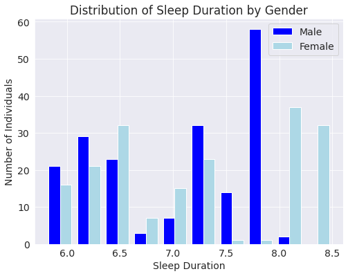

```python
plt.figure(figsize=(8, 6))


plt.hist([sleep_clean_df[sleep_clean_df['Gender'] == 'Male']['Sleep Duration'],
          sleep_clean_df[sleep_clean_df['Gender'] == 'Female']['Sleep Duration']],
         bins=10, alpha=1, label=['Male', 'Female'], color=['blue', 'lightblue'])
plt.xlabel('Sleep Duration')
plt.ylabel('Number of Individuals')
plt.title('Distribution of Sleep Duration by Gender')
plt.legend()
plt.show()
```

## Graph 2: Sleep Duration and Occupation

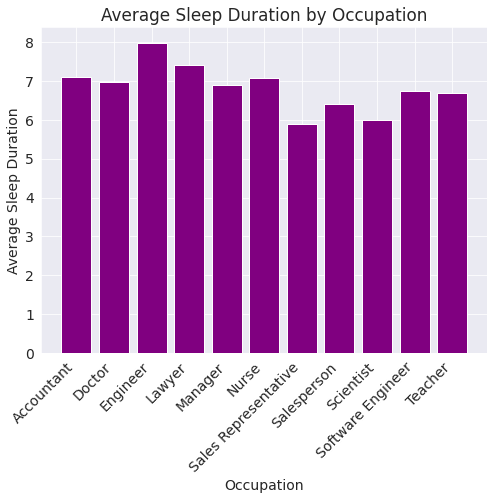

```python
avg_sleep = sleep_clean_df.groupby('Occupation')['Sleep Duration'].mean().reset_index()
plt.figure(figsize=(8, 6))
plt.bar(avg_sleep['Occupation'], avg_sleep['Sleep Duration'], color='purple')
plt.xlabel('Occupation')
plt.ylabel('Average Sleep Duration')
plt.title('Average Sleep Duration by Occupation')
plt.xticks(rotation=45, ha='right')  # Rotating x-labels for better readability
plt.show()
```

## Graph 3: Sleeping Disorders

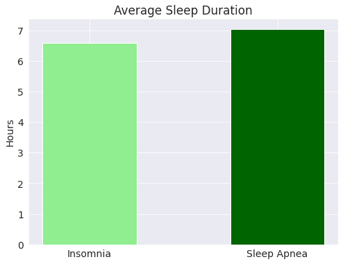

```python
# Filtering data for people with insomnia and sleep apnea
insomnia_data = sleep_clean_df[sleep_clean_df['Sleep Disorder'] == 'Insomnia']
sleep_apnea_data = sleep_clean_df[sleep_clean_df['Sleep Disorder'] == 'Sleep Apnea']

# Plot 1: Comparison of average sleep duration
avg_sleep_insomnia = insomnia_data['Sleep Duration'].mean()
avg_sleep_apnea = sleep_apnea_data['Sleep Duration'].mean()

labels = ['Insomnia', 'Sleep Apnea']
average_sleep = [avg_sleep_insomnia, avg_sleep_apnea]

plt.figure(figsize=(8, 6))
plt.bar(labels, average_sleep, width = 0.5, color=['lightgreen', 'darkgreen'])
plt.title('Average Sleep Duration')
plt.ylabel('Hours')
plt.show()
```

The bar chart displays average sleep durations for individuals with insomnia compared to those with sleep apnea. Surprisingly, individuals with insomnia average over 6 hours of sleep, which challenges the common perception of this condition involving severely reduced sleep. Those with sleep apnea, a disorder characterized by disrupted breathing during sleep, show a higher average of nearly 7 hours. This suggests that while sleep apnea patients may achieve longer sleep, the restorative quality of their sleep could be compromised, consistent with the condition's symptomatic nighttime disturbances. Insomnia's impact, often associated with prolonged sleep onset and frequent waking, appears less severe in terms of sleep quantity in this sample. Both conditions contribute to significant health challenges, such as cardiovascular risks and daytime impairment, highlighting the complex nature of sleep disorders where both duration and quality are crucial for understanding their full impact on well-being.

## Graph 4: BMI and Sleeping Disorders

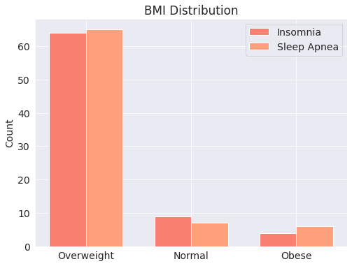

```python
# Calculate BMI distribution
bmi_insomnia = insomnia_data['BMI Category'].value_counts()
bmi_sleep_apnea = sleep_apnea_data['BMI Category'].value_counts()

labels = bmi_insomnia.index.union(bmi_sleep_apnea.index).tolist()
x = np.arange(len(labels))  # Label locations
width = 0.35  # Width of the bars

# Create bar plot
plt.figure(figsize=(8, 6))
plt.bar(x - width/2, bmi_insomnia.reindex(labels).fillna(0), width, color = 'salmon', label='Insomnia')
plt.bar(x + width/2, bmi_sleep_apnea.reindex(labels).fillna(0), width, color = 'lightsalmon',label='Sleep Apnea')

plt.ylabel('Count')
plt.title('BMI Distribution')
plt.xticks(x, labels)
plt.legend()
plt.show()
```

The bar chart illustrates the BMI distribution among individuals with insomnia and sleep apnea. Both conditions most frequently occur in individuals classified as overweight, followed by those in the normal and obese categories. Notably, the count of overweight individuals is roughly equal for both sleep disorders, suggesting that excess weight might be a common risk factor. However, the representation of obese individuals is noticeably higher in the sleep apnea group, which aligns with clinical observations that sleep apnea is often associated with higher obesity rates. This could be due to the fact that excess body weight can contribute to obstructed breathing during sleep. In contrast, the distribution of normal BMI among individuals with insomnia and sleep apnea is significantly lower, indicating that normal weight individuals are less represented in this dataset's sleep disorder population. The data underscores the potential link between body weight and the prevalence of sleep disorders, emphasizing the importance of considering BMI in the management and treatment of sleep-related conditions.

## Graph 5: Age and Sleeping Disorders

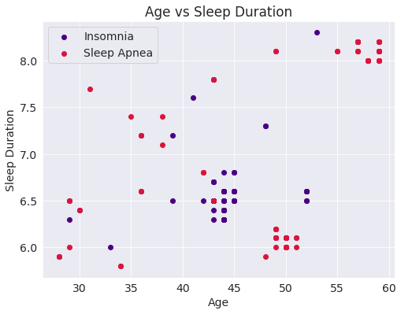

```python
scatter_insomnia = insomnia_data[['Age', 'Sleep Duration']]
scatter_sleep_apnea = sleep_apnea_data[['Age', 'Sleep Duration']]

plt.figure(figsize=(8, 6))
plt.scatter(scatter_insomnia['Age'], scatter_insomnia['Sleep Duration'], label='Insomnia', color = 'indigo')
plt.scatter(scatter_sleep_apnea['Age'], scatter_sleep_apnea['Sleep Duration'], label='Sleep Apnea', color = 'crimson')

plt.xlabel('Age')
plt.ylabel('Sleep Duration')
plt.title('Age vs Sleep Duration')
plt.legend()
plt.show()
```

## Graph 6: Sleep Duration and Blood Pressure

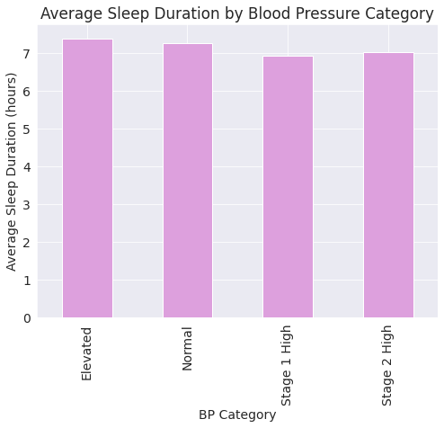

```python
def categorize_blood_pressure(bp):
    systolic, diastolic = map(int, bp.split('/'))
    if systolic < 120 and diastolic <= 80:
        return 'Normal'
    elif 120 <= systolic <= 129 and diastolic <= 80:
        return 'Elevated'
    elif 130 <= systolic <= 139 or 80 <= diastolic <= 89:
        return 'Stage 1 High'
    elif systolic >= 140 or 80 <= diastolic <= 89:
        return 'Stage 2 High'

# Apply the function to the Blood Pressure column
sleep_clean_df['BP Category'] = sleep_clean_df['Blood Pressure'].apply(categorize_blood_pressure)

# Group by BP Category and calculate average sleep duration
avg_sleep_by_bp = sleep_clean_df.groupby('BP Category')['Sleep Duration'].mean()

# Plotting
plt.figure(figsize=(8, 6))
avg_sleep_by_bp.plot(kind='bar', color = 'plum')
plt.title('Average Sleep Duration by Blood Pressure Category')
plt.ylabel('Average Sleep Duration (hours)')
plt.show()
```

## Graph 7: Blood Pressure and Age

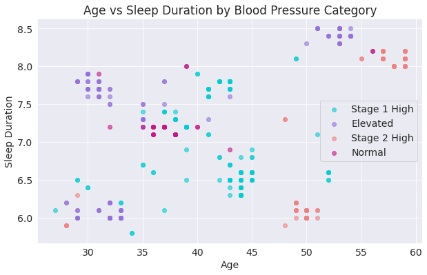

```python
category_colors = {
    'Normal': 'mediumvioletred',
    'Elevated': 'mediumpurple',
    'Stage 1 High': 'darkturquoise',
    'Stage 2 High': 'lightcoral'
}

# Scatter plot for age vs. sleep duration for each BP category
plt.figure(figsize=(10, 6))
for category in sleep_clean_df['BP Category'].unique():
    subset = sleep_clean_df[sleep_clean_df['BP Category'] == category]
    plt.scatter(subset['Age'], subset['Sleep Duration'], label=category, alpha=0.6,color=category_colors[category])

plt.title('Age vs Sleep Duration by Blood Pressure Category')
plt.xlabel('Age')
plt.ylabel('Sleep Duration')
plt.legend()
plt.show()
```

This scatter plot visualizes the relationship between age and sleep duration across different blood pressure categories. The data points are spread across ages 30 to 60 and show a range of sleep durations from just above 6 hours to 8.5 hours, regardless of blood pressure status.

The distribution does not indicate a clear pattern or trend of sleep duration varying with age within any blood pressure category. Individuals with normal blood pressure, elevated blood pressure, and stages 1 and 2 high blood pressure appear to have a wide variation in sleep duration, with no distinct differences between the categories.

## Graphs 8-10: Sleep and Lifestyle Choices

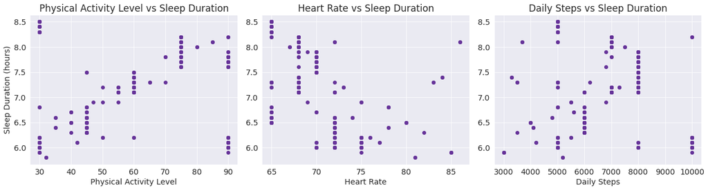

```python
import matplotlib.pyplot as plt

# Assuming 'df' is your DataFrame and it contains 'Sleep Duration' along with the other variables
fig, axes = plt.subplots(1, 3, figsize=(18, 5))

# Scatter plot for Physical Activity Level vs Sleep Duration
axes[0].scatter(sleep_clean_df['Physical Activity Level'], sleep_clean_df['Sleep Duration'], color ='rebeccapurple')
axes[0].set_title('Physical Activity Level vs Sleep Duration')
axes[0].set_xlabel('Physical Activity Level')
axes[0].set_ylabel('Sleep Duration (hours)')

# Scatter plot for Heart Rate vs Sleep Duration
axes[1].scatter(sleep_clean_df['Heart Rate'], sleep_clean_df['Sleep Duration'], color ='rebeccapurple')
axes[1].set_title('Heart Rate vs Sleep Duration')
axes[1].set_xlabel('Heart Rate')

# Scatter plot for Daily Steps vs Sleep Duration
axes[2].scatter(sleep_clean_df['Daily Steps'], sleep_clean_df['Sleep Duration'], color ='rebeccapurple')
axes[2].set_title('Daily Steps vs Sleep Duration')
axes[2].set_xlabel('Daily Steps')

plt.tight_layout()
plt.show()
```

The set of scatter plots represents sleep duration against three variables: physical activity level, heart rate, and daily steps. Across the board, sleep duration varies without a clear or consistent pattern in relation to these variables.

In the first plot, physical activity levels range widely, but there's no distinct trend suggesting higher activity levels lead to longer sleep durations. Similarly, the second plot shows no obvious correlation between heart rate and sleep duration. The third plot, concerning daily steps, also fails to display a clear relationship with sleep duration. While there are clusters of data points at higher step counts correlating with longer sleep durations, the overall spread does not indicate a strong or linear association.

These visualizations suggest that within the dataset, the simple measures of physical activity, heart rate, and daily steps may not be directly predictive of sleep duration. It's possible that the interrelations between sleep duration and these variables are more nuanced, potentially influenced by other factors not captured in these plots. It underscores the complexity of sleep as a physiological process influenced by a multitude of interdependent factors.

Let us save and upload our work to Jovian before continuing

```python
import jovian
```

```python
jovian.commit()
```

```
[jovian] Updating notebook "insiyah-yu/sleep-health-and-lifestyle-project" on https://jovian.com
[jovian] Committed successfully! https://jovian.com/insiyah-yu/sleep-health-and-lifestyle-project
```

```
'https://jovian.com/insiyah-yu/sleep-health-and-lifestyle-project'
```

## Asking and Answering Questions

#### Q1: Quality of Sleep and Sleeping Disorders

In the third visualization, we analyzed the influence of sleep disorders on the duration of sleep among individuals, revealing that conditions such as insomnia and sleep apnea may not significantly reduce the total hours of sleep. However, these disorders could potentially compromise the quality of sleep, which is a crucial component of overall health. To further investigate this, we will delve into the dataset to examine the nuances of how sleep disorders, notably insomnia and sleep apnea, impact the subjective quality of sleep as reported by the individuals. By scrutinizing this aspect, we aim to uncover the subtler, qualitative aspects of sleep that quantitative measures alone may overlook. This analysis could provide valuable insights into the broader implications of sleep disorders on well-being and daily functioning.

```python
average_quality_sleep = pd.pivot_table(
    sleep_clean_df[sleep_clean_df['Sleep Disorder'].isin(['Insomnia', 'Sleep Apnea'])],
    values='Quality of Sleep',
    index='Sleep Disorder',
    aggfunc='mean'
).reset_index()
average_quality_sleep
```

|  | Sleep Disorder | Quality of Sleep |
| --- | --- | --- |
| 0 | Insomnia | 6.532468 |
| 1 | Sleep Apnea | 7.205128 |

The findings from our dataset yield a somewhat surprising narrative: individuals who are affected by sleep apnea not only tend to achieve longer periods of sleep but also report, on average, a superior quality of sleep when compared to those grappling with insomnia. This revelation is counterintuitive, as sleep apnea is typically associated with fragmented sleep that could be presumed to diminish sleep quality. Conversely, despite insomnia being characterized by significant difficulties in initiating and maintaining sleep, it is traditionally not associated with the frequent nocturnal awakenings characteristic of sleep apnea. These unexpected results underscore the complexity of sleep disorders and their multifaceted impact on sleep quality, suggesting that the subjective experience of sleep quality may not always align with the clinical symptoms presented by these conditions.

#### Q2: Quality of Sleep, Age and Sleeping Disorders

In the fifth graph, our analysis revealed a lack of a distinct trend correlating age with sleep duration for individuals suffering from either insomnia or sleep apnea. This intriguing observation prompts a deeper exploration into the dataset to understand how the quality of sleep is influenced by a combination of factors - namely, the type of sleeping disorder and the age of the individual.

```python
pd.pivot_table(
    sleep_clean_df[sleep_clean_df['Sleep Disorder'].isin(['Insomnia', 'Sleep Apnea'])],
    values='Quality of Sleep',
    index=['Sleep Disorder', 'Age'],
    aggfunc='mean'
).reset_index()
```

|  | Sleep Disorder | Age | Quality of Sleep |
| --- | --- | --- | --- |
| 0 | Insomnia | 28 | 4.000000 |
| 1 | Insomnia | 29 | 5.500000 |
| 2 | Insomnia | 30 | 5.000000 |
| 3 | Insomnia | 33 | 6.000000 |
| 4 | Insomnia | 36 | 6.500000 |
| 5 | Insomnia | 39 | 6.500000 |
| 6 | Insomnia | 41 | 8.000000 |
| 7 | Insomnia | 42 | 6.000000 |
| 8 | Insomnia | 43 | 6.411765 |
| 9 | Insomnia | 44 | 6.428571 |
| 10 | Insomnia | 45 | 7.000000 |
| 11 | Insomnia | 48 | 7.000000 |
| 12 | Insomnia | 50 | 6.000000 |
| 13 | Insomnia | 52 | 7.000000 |
| 14 | Insomnia | 53 | 9.000000 |
| 15 | Sleep Apnea | 28 | 4.000000 |
| 16 | Sleep Apnea | 29 | 5.500000 |
| 17 | Sleep Apnea | 30 | 5.000000 |
| 18 | Sleep Apnea | 31 | 7.000000 |
| 19 | Sleep Apnea | 34 | 4.000000 |
| 20 | Sleep Apnea | 35 | 7.000000 |
| 21 | Sleep Apnea | 36 | 6.500000 |
| 22 | Sleep Apnea | 38 | 7.500000 |
| 23 | Sleep Apnea | 42 | 6.000000 |
| 24 | Sleep Apnea | 43 | 7.000000 |
| 25 | Sleep Apnea | 48 | 6.000000 |
| 26 | Sleep Apnea | 49 | 6.600000 |
| 27 | Sleep Apnea | 50 | 6.000000 |
| 28 | Sleep Apnea | 51 | 6.000000 |
| 29 | Sleep Apnea | 55 | 9.000000 |
| 30 | Sleep Apnea | 57 | 9.000000 |
| 31 | Sleep Apnea | 58 | 9.000000 |
| 32 | Sleep Apnea | 59 | 9.000000 |

The dataset reveals intriguing insights into the quality of sleep among individuals with insomnia and sleep apnea across different ages. For those with insomnia, a trend of gradually improving sleep quality is observed with increasing age. Young adults in their late 20s and early 30s report lower quality scores (around 4 to 5), but this improves to scores of 6 to 7 by the late 40s and peaks at age 53 with a score of 9.

In contrast, individuals with sleep apnea exhibit a less consistent pattern. While similarly lower quality scores are noted in the late 20s, there's a quicker improvement to scores of 7 in the early 30s. The quality of sleep fluctuates in the 40s, but significantly, older age groups, particularly in the mid to late 50s, consistently report high sleep quality scores of 9.

These findings suggest that while age might influence sleep quality in those suffering from sleep disorders, the trajectory of this influence differs between insomnia and sleep apnea. The marked improvement in sleep quality among older individuals with sleep apnea is especially notable, indicating potential age-related adaptations or effective management strategies for the disorder in later life.

#### Q3: Heart Rate and Sleep

How does heart rate impact an individual's sleep patterns?

```python
sleep_clean_df.groupby('Heart Rate').agg({'Sleep Duration': 'mean', 'Quality of Sleep': 'mean'})
```

| Heart Rate | Sleep Duration | Quality of Sleep |
| --- | --- | --- |
| 65 | 7.577612 | 8.104478 |
| 67 | 8.000000 | 9.000000 |
| 68 | 7.523404 | 8.329787 |
| 69 | 7.400000 | 7.000000 |
| 70 | 7.561842 | 7.394737 |
| 72 | 6.385507 | 6.246377 |
| 73 | 7.200000 | 8.000000 |
| 74 | 6.600000 | 5.000000 |
| 75 | 6.119444 | 6.055556 |
| 76 | 6.200000 | 6.000000 |
| 77 | 6.100000 | 6.000000 |
| 78 | 6.640000 | 5.800000 |
| 80 | 6.500000 | 5.000000 |
| 81 | 5.800000 | 4.000000 |
| 82 | 6.300000 | 6.000000 |
| 83 | 7.300000 | 7.000000 |
| 84 | 7.400000 | 7.000000 |
| 85 | 5.900000 | 4.000000 |
| 86 | 8.100000 | 9.000000 |

The results indicate a relationship between heart rate and sleep metrics such as sleep duration and quality of sleep. As heart rate values vary, so do the corresponding sleep patterns.

For instance, individuals with heart rates around 67 and 86 have notably higher sleep quality ratings, with quality scores of 9.0. In contrast, heart rates around 81 and 85 seem to correlate with lower sleep quality, with quality scores of 4.0.

These findings suggest that there may be a connection between heart rate and sleep, with lower heart rates generally associated with longer sleep duration and higher sleep quality. However, it's important to note that these are observational results, and many factors can influence sleep, so further research and consideration of confounding variables would be necessary to draw definitive conclusions about causation.

#### Q3: Stress Levels and Quality of Sleep

Do gender-related differences exist in susceptibility to higher stress levels, and if so, how does this gender disparity impact sleep quality?

```python
sleep_clean_df.groupby('Gender')[['Stress Level', 'Quality of Sleep']].mean()
```

| Gender | Stress Level | Quality of Sleep |
| --- | --- | --- |
| Female | 4.675676 | 7.664865 |
| Male | 6.079365 | 6.968254 |

The analysis of stress levels and sleep quality by gender reveals notable differences between females and males.

On average, females in the dataset report lower stress levels (mean of approximately 4.68) compared to males, who report higher stress levels (mean of approximately 6.08). This suggests that, within this sample, females tend to experience lower levels of perceived stress.

In terms of sleep quality, females also report higher mean scores (approximately 7.66) compared to males (approximately 6.97). This indicates that, on average, females in the dataset tend to report better sleep quality.

These findings suggest a potential correlation between gender, stress levels, and sleep quality, with females in this dataset reporting lower stress levels and better sleep quality compared to males.

#### Q4: Men and Women in the Workplace: Sleep and Stress

This compelling heading explores the intricate interplay between gender, professional life, sleep patterns, and stress levels. Delving into various occupations, it sheds light on how men and women navigate their work environments, revealing intriguing insights into their unique sleep habits and the stress they encounter along the way. Discover the disparities and commonalities in the way gender impacts the world of work, rest, and well-being.

```python
sleep_clean_df.groupby(['Occupation', 'Gender'])[['Sleep Duration', 'Quality of Sleep', 'Stress Level']].mean()
```

| Occupation | Gender | Sleep Duration | Quality of Sleep | Stress Level |
| --- | --- | --- | --- | --- |
| Accountant | Female | 7.111111 | 7.888889 | 4.555556 |
|  | Male | 7.200000 | 8.000000 | 6.000000 |
| Doctor | Female | 8.200000 | 9.000000 | 3.000000 |
|  | Male | 6.934783 | 6.579710 | 6.840580 |
| Engineer | Female | 8.425000 | 9.000000 | 3.000000 |
|  | Male | 7.535484 | 7.806452 | 4.806452 |
| Lawyer | Female | 7.150000 | 7.000000 | 5.500000 |
|  | Male | 7.422222 | 7.933333 | 5.044444 |
| Manager | Female | 6.900000 | 7.000000 | 5.000000 |
| Nurse | Female | 7.063014 | 7.369863 | 5.547945 |
| Sales Representative | Male | 5.900000 | 4.000000 | 8.000000 |
| Salesperson | Male | 6.403125 | 6.000000 | 7.000000 |
| Scientist | Female | 6.000000 | 5.000000 | 7.000000 |
| Software Engineer | Male | 6.750000 | 6.500000 | 6.000000 |
| Teacher | Female | 6.705714 | 7.114286 | 4.285714 |
|  | Male | 6.580000 | 6.000000 | 6.200000 |

The analysis of sleep-related factors, including sleep duration, quality of sleep, and stress level, across various occupations and genders reveals interesting patterns.

These results highlight potential gender and occupation-related variations in sleep and stress.

#### Q5: Age, Stress and Sleep

```python
sleep_clean_df.groupby(['Age', 'Gender'])[['Sleep Duration', 'Quality of Sleep', 'Stress Level']].mean()
```

| Age | Gender | Sleep Duration | Quality of Sleep | Stress Level |
| --- | --- | --- | --- | --- |
| 27 | Male | 6.100000 | 6.000000 | 6.000000 |
| 28 | Male | 6.020000 | 4.800000 | 8.000000 |
| 29 | Female | 6.500000 | 5.000000 | 7.000000 |
|  | Male | 6.700000 | 6.363636 | 7.181818 |
| 30 | Female | 6.400000 | 5.000000 | 7.000000 |
|  | Male | 7.781818 | 7.000000 | 6.000000 |
| 31 | Female | 7.900000 | 8.000000 | 4.000000 |
|  | Male | 7.417647 | 6.823529 | 6.352941 |
| 32 | Male | 6.588235 | 6.529412 | 6.941176 |
| 33 | Female | 6.200000 | 6.000000 | 6.000000 |
|  | Male | 6.036364 | 6.000000 | 8.000000 |
| 34 | Female | 5.800000 | 4.000000 | 8.000000 |
| 35 | Female | 7.200000 | 8.000000 | 4.000000 |
|  | Male | 7.218182 | 7.727273 | 4.454545 |
| 36 | Female | 7.160000 | 8.000000 | 4.000000 |
|  | Male | 6.600000 | 5.000000 | 7.000000 |
| 37 | Female | 7.146667 | 7.866667 | 4.133333 |
|  | Male | 7.560000 | 8.000000 | 4.600000 |
| 38 | Female | 7.133333 | 7.888889 | 4.111111 |
|  | Male | 7.227273 | 8.000000 | 5.000000 |
| 39 | Female | 7.633333 | 8.333333 | 4.000000 |
|  | Male | 7.141667 | 7.750000 | 5.166667 |
| 40 | Female | 7.200000 | 8.000000 | 6.000000 |
|  | Male | 7.900000 | 8.000000 | 5.000000 |
| 41 | Male | 7.533333 | 7.833333 | 5.250000 |
| 42 | Female | 6.800000 | 6.000000 | 7.000000 |
|  | Male | 7.614286 | 7.714286 | 5.285714 |
| 43 | Female | 6.700000 | 7.000000 | 4.000000 |
|  | Male | 7.193548 | 7.096774 | 5.870968 |
| 44 | Female | 6.563636 | 7.000000 | 4.000000 |
|  | Male | 6.368421 | 6.052632 | 7.000000 |
| 45 | Female | 6.621429 | 7.000000 | 4.357143 |
| 48 | Female | 5.900000 | 6.000000 | 8.000000 |
|  | Male | 7.300000 | 7.000000 | 5.000000 |
| 49 | Female | 6.133333 | 6.000000 | 8.000000 |
|  | Male | 8.100000 | 9.000000 | 3.000000 |
| 50 | Female | 6.155000 | 6.150000 | 7.750000 |
| 51 | Female | 7.412500 | 7.625000 | 5.250000 |
| 52 | Female | 7.177778 | 7.666667 | 5.666667 |
| 53 | Female | 8.423529 | 9.000000 | 3.000000 |
| 54 | Female | 8.414286 | 9.000000 | 3.000000 |
| 55 | Female | 8.100000 | 9.000000 | 4.000000 |
| 56 | Female | 8.200000 | 9.000000 | 3.000000 |
| 57 | Female | 8.155556 | 9.000000 | 3.000000 |
| 58 | Female | 8.000000 | 9.000000 | 3.000000 |
| 59 | Female | 8.093750 | 9.000000 | 3.000000 |

In conclusion, this data underscores the complex interplay between age, gender, sleep patterns, and stress levels. While some trends emerge, such as females generally reporting better sleep quality, the relationship between age and stress is less straightforward.

Let us save and upload our work to Jovian before continuing.

```python
import jovian
```

```python
jovian.commit()
```

```
[jovian] Updating notebook "insiyah-yu/sleep-health-and-lifestyle-project" on https://jovian.com
[jovian] Committed successfully! https://jovian.com/insiyah-yu/sleep-health-and-lifestyle-project
```

```
'https://jovian.com/insiyah-yu/sleep-health-and-lifestyle-project'
```

## Inferences and Conclusion

The relationship between sleep health and lifestyle is multifaceted, with various parameters such as age, occupation, stress level, BMI, heart rate, sleep disorders, and blood pressure all playing pivotal roles.

General lifestyle choices, including daily routines, exercise habits, and stress management, significantly impact sleep quality and duration. Different age groups and occupational demands can influence sleep patterns, and stress levels often correlate with sleep disturbances.

It's important to note that all the analyses conducted are based on a single dataset and should be interpreted as specific to the data within that set. These findings may not necessarily be indicative of trends or characteristics within the broader general population, as the dataset's composition, size, and demographics can influence the observed results. For a more comprehensive and reliable understanding of sleep health and lifestyle patterns in the general population, broader and more diverse datasets, along with additional research, would be needed.

```python
import jovian
```

```python
jovian.commit()
```

```
[jovian] Updating notebook "insiyah-yu/sleep-health-and-lifestyle-project" on https://jovian.com
[jovian] Committed successfully! https://jovian.com/insiyah-yu/sleep-health-and-lifestyle-project
```

```
'https://jovian.com/insiyah-yu/sleep-health-and-lifestyle-project'
```